# PCA_Titanic

### Niranjan111@hotmail.com Principal Component Analysis

```python
import numpy as np
import pandas as pd
import matplotlib.pyplot as plt
import seaborn as sns
sns.set
```

```
<function seaborn.rcmod.set(context='notebook', style='darkgrid', palette='deep', font='sans-serif', font_scale=1, color_codes=True, rc=None)>
```

#### Lets first import the titanic (train data set for this anaysis)

```python
train = pd.read_pickle(r"C:\Users\Niranjan.p\Desktop\Home work and assignments\machine learning\Kaggle\titanic\new_train.pkl")
```

```python
train.info()
```

```
<class 'pandas.core.frame.DataFrame'>
RangeIndex: 891 entries, 0 to 890
Data columns (total 19 columns):
 #   Column         Non-Null Count  Dtype
---  ------         --------------  -----
 0   Survived       891 non-null    int64
 1   Age            891 non-null    float64
 2   SibSp          891 non-null    int64
 3   Parch          891 non-null    int64
 4   Fare           891 non-null    float64
 5   Pclass_2       891 non-null    uint8
 6   Pclass_3       891 non-null    uint8
 7   Sex_male       891 non-null    uint8
 8   Cabin_No_info  891 non-null    uint8
 9   Embarked_Q     891 non-null    uint8
 10  Embarked_S     891 non-null    uint8
 11  Title_Miss     891 non-null    uint8
 12  Title_Mr       891 non-null    uint8
 13  Title_Mrs      891 non-null    uint8
 14  Title_Other    891 non-null    uint8
 15  Tick_CA        891 non-null    uint8
 16  Tick_No_info   891 non-null    uint8
 17  Tick_Other     891 non-null    uint8
 18  Tick_PC        891 non-null    uint8
dtypes: float64(2), int64(3), uint8(14)
memory usage: 47.1 KB
```

### Lets drop the survided variable because we are not intreseted in y-variable at least for this asignment

```python
train = train.drop('Survived',axis=1)
```

```python
train.info()
```

```
<class 'pandas.core.frame.DataFrame'>
RangeIndex: 891 entries, 0 to 890
Data columns (total 18 columns):
 #   Column         Non-Null Count  Dtype
---  ------         --------------  -----
 0   Age            891 non-null    float64
 1   SibSp          891 non-null    int64
 2   Parch          891 non-null    int64
 3   Fare           891 non-null    float64
 4   Pclass_2       891 non-null    uint8
 5   Pclass_3       891 non-null    uint8
 6   Sex_male       891 non-null    uint8
 7   Cabin_No_info  891 non-null    uint8
 8   Embarked_Q     891 non-null    uint8
 9   Embarked_S     891 non-null    uint8
 10  Title_Miss     891 non-null    uint8
 11  Title_Mr       891 non-null    uint8
 12  Title_Mrs      891 non-null    uint8
 13  Title_Other    891 non-null    uint8
 14  Tick_CA        891 non-null    uint8
 15  Tick_No_info   891 non-null    uint8
 16  Tick_Other     891 non-null    uint8
 17  Tick_PC        891 non-null    uint8
dtypes: float64(2), int64(2), uint8(14)
memory usage: 40.2 KB
```

### Our data contains age divided by 10 and Fare divide by hundred lets convert to original before scaling (we can scale in the already scaled data but lets do it anyway)

```python
train['Age']=train['Age']*10
train['Fare']=train['Fare']*100
```

```python
train.describe().T
```

|  | count | mean | std | min | 25% | 50% | 75% | max |
| --- | --- | --- | --- | --- | --- | --- | --- | --- |
| Age | 891.0 | 29.856532 | 13.292134 | 0.42 | 22.0000 | 30.0000 | 36.0 | 80.0000 |
| SibSp | 891.0 | 0.523008 | 1.102743 | 0.00 | 0.0000 | 0.0000 | 1.0 | 8.0000 |
| Parch | 891.0 | 0.381594 | 0.806057 | 0.00 | 0.0000 | 0.0000 | 0.0 | 6.0000 |
| Fare | 891.0 | 32.204208 | 49.693429 | 0.00 | 7.9104 | 14.4542 | 31.0 | 512.3292 |
| Pclass_2 | 891.0 | 0.206510 | 0.405028 | 0.00 | 0.0000 | 0.0000 | 0.0 | 1.0000 |
| Pclass_3 | 891.0 | 0.551066 | 0.497665 | 0.00 | 0.0000 | 1.0000 | 1.0 | 1.0000 |
| Sex_male | 891.0 | 0.647587 | 0.477990 | 0.00 | 0.0000 | 1.0000 | 1.0 | 1.0000 |
| Cabin_No_info | 891.0 | 0.771044 | 0.420397 | 0.00 | 1.0000 | 1.0000 | 1.0 | 1.0000 |
| Embarked_Q | 891.0 | 0.086420 | 0.281141 | 0.00 | 0.0000 | 0.0000 | 0.0 | 1.0000 |
| Embarked_S | 891.0 | 0.725028 | 0.446751 | 0.00 | 0.0000 | 1.0000 | 1.0 | 1.0000 |
| Title_Miss | 891.0 | 0.204265 | 0.403390 | 0.00 | 0.0000 | 0.0000 | 0.0 | 1.0000 |
| Title_Mr | 891.0 | 0.580247 | 0.493796 | 0.00 | 0.0000 | 1.0000 | 1.0 | 1.0000 |
| Title_Mrs | 891.0 | 0.140292 | 0.347485 | 0.00 | 0.0000 | 0.0000 | 0.0 | 1.0000 |
| Title_Other | 891.0 | 0.030303 | 0.171516 | 0.00 | 0.0000 | 0.0000 | 0.0 | 1.0000 |
| Tick_CA | 891.0 | 0.046016 | 0.209637 | 0.00 | 0.0000 | 0.0000 | 0.0 | 1.0000 |
| Tick_No_info | 891.0 | 0.760943 | 0.426747 | 0.00 | 1.0000 | 1.0000 | 1.0 | 1.0000 |
| Tick_Other | 891.0 | 0.102132 | 0.302992 | 0.00 | 0.0000 | 0.0000 | 0.0 | 1.0000 |
| Tick_PC | 891.0 | 0.067340 | 0.250751 | 0.00 | 0.0000 | 0.0000 | 0.0 | 1.0000 |

```python
### Scaling the feature space
```

```python
from sklearn.preprocessing import StandardScaler
sc = StandardScaler()
train = sc.fit_transform(train)
```

```python
from sklearn.decomposition import PCA
```

### Lets aplly the PCA to the train dataset

```python
pca=PCA(n_components=4) ### Lets just take 4 components and try
pca.fit(train)
```

```
PCA(copy=True, iterated_power='auto', n_components=4, random_state=None,
    svd_solver='auto', tol=0.0, whiten=False)
```

```python
print(pca.components_)
```

```
[[-0.05457261  0.1715575   0.24536263  0.30843413  0.05572493 -0.24285268
  -0.47069687 -0.23787378 -0.01742201 -0.10640443  0.30552852 -0.47845475
   0.27713362  0.05349548  0.07497931 -0.10923219 -0.03028226  0.20001452]
 [ 0.37448965 -0.19851842 -0.164005    0.27732626  0.09348525 -0.41970554
   0.20424087 -0.34281707 -0.21902644 -0.00295212 -0.28146693  0.21364086
   0.02374784  0.16020944 -0.06596543 -0.21609137  0.06251115  0.34406016]
 [-0.11102335  0.26029013  0.23189583 -0.07458984  0.31501552 -0.07378589
   0.07267998  0.17530972 -0.36374093  0.41609888 -0.12524784  0.0288717
   0.0599752  -0.06793171  0.38900458 -0.35343557  0.31186241 -0.12732254]
 [-0.18421992  0.21959457  0.07685815  0.22981301 -0.37947693  0.25122038
   0.16314683  0.00146962  0.14313415 -0.27851627  0.08982598  0.13885854
  -0.32451107 -0.08609622  0.18214598 -0.44586914  0.17076321  0.35513515]]
```

#### The above arrays shows the loadings of each features to the respective Pricipal components.

```python
print(pca.explained_variance_ratio_)
```

```
[0.17531804 0.14025844 0.11580466 0.09688225]
```

#### Next let is make the scree plot to see the optimal number of components

```python
pca=PCA(n_components=17)
pca.fit(train)
```

```
PCA(copy=True, iterated_power='auto', n_components=17, random_state=None,
    svd_solver='auto', tol=0.0, whiten=False)
```

```python
pca.explained_variance_ratio_
```

```
array([0.17531804, 0.14025844, 0.11580466, 0.09688225, 0.08458101,
       0.06607954, 0.06385571, 0.05436072, 0.04619798, 0.04142107,
       0.03074867, 0.02894996, 0.02179407, 0.02037022, 0.00525408,
       0.00443775, 0.0031261 ])
```

```python
PVE=pd.DataFrame({'PVE':pca.explained_variance_ratio_, 'Principal Component':range(1,pca.n_components+1)})
PVE.head()
```

|  | PVE | Principal Component |
| --- | --- | --- |
| 0 | 0.175318 | 1 |
| 1 | 0.140258 | 2 |
| 2 | 0.115805 | 3 |
| 3 | 0.096882 | 4 |
| 4 | 0.084581 | 5 |

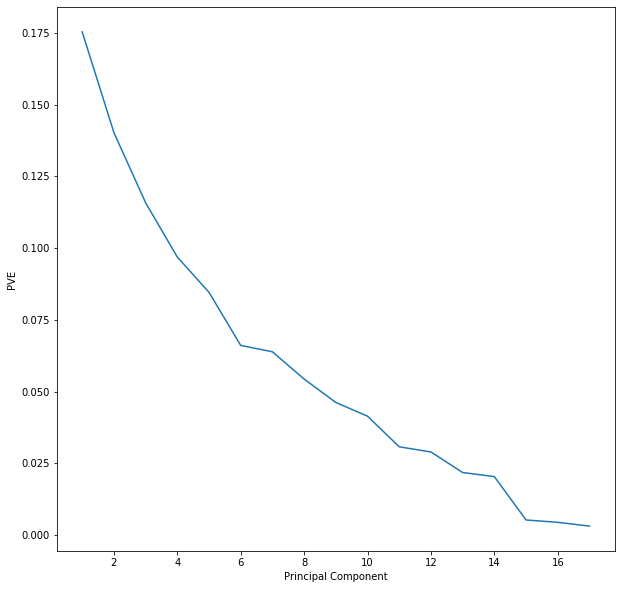

```python
plt.figure(figsize=(10,10))
sns.lineplot(x='Principal Component', y='PVE', data=PVE)
plt.show()
```

Looks like the choice here is little though but still the 4 number of components we made earlier make some sense or we can go with the 6 components as well, all of it depends on which type of analysis we want to run after doing the principal component analysis, due to which there is no exact number to take. If you make 4 components it still describes (0.18 +0.14 + 0.12 + 0.1 = 0.54% of variation) and if we take 6 components its explains about 67% of the variation in the data.

## Part 2 Kernel PCA

```python
from sklearn.decomposition import KernelPCA
```

```python
### First lets try simple KernelPCa with 'rbf' kernel and 17 components with other values as default
kpca= KernelPCA(n_components = 17, kernel = 'rbf')
```

```python
K_train = kpca.fit_transform(train)
```

The above code transforms our fetaure space into 17 componets using the KernelPCA. To establish the variance we can calulate variance ourself

```python
Var = np.var(K_train, axis=0)
Var
```

```
array([0.12135618, 0.05598423, 0.0469956 , 0.04256026, 0.03711571,
       0.03298816, 0.02681338, 0.02082696, 0.01924402, 0.01663237,
       0.01543063, 0.01470089, 0.01264169, 0.01189306, 0.0109184 ,
       0.01014901, 0.00990172])
```

```python
PVE =  Var/ np.sum(Var)
PVE
```

```
array([0.2397622 , 0.11060749, 0.09284874, 0.08408587, 0.07332915,
       0.06517437, 0.05297493, 0.04114762, 0.03802023, 0.0328604 ,
       0.03048614, 0.02904439, 0.02497606, 0.023497  , 0.02157137,
       0.0200513 , 0.01956273])
```

```python
np.cumsum(PVE)
```

```
array([0.2397622 , 0.3503697 , 0.44321843, 0.52730431, 0.60063345,
       0.66580782, 0.71878276, 0.75993038, 0.79795061, 0.83081101,
       0.86129715, 0.89034154, 0.9153176 , 0.9388146 , 0.96038597,
       0.98043727, 1.        ])
```

```python
np.sum(Var)
```

```
0.5061522623587905
```

```python
### lets look at the Eigen values of components
kpca.lambdas_
```

```
array([108.12835769,  49.8819515 ,  41.87307798,  37.92118761,
        33.07010019,  29.39244644,  23.89072284,  18.55682439,
        17.14642483,  14.81943831,  13.74869082,  13.09848959,
        11.26374384,  10.59671716,   9.72829061,   9.04276835,
         8.82243361])
```

```python
### Plotting the eigen values
```

```python
Eig=pd.DataFrame({'eigen':kpca.lambdas_, 'Principal Component':range(1,kpca.n_components+1)})
Eig.head()
```

|  | eigen | Principal Component |
| --- | --- | --- |
| 0 | 108.128358 | 1 |
| 1 | 49.881951 | 2 |
| 2 | 41.873078 | 3 |
| 3 | 37.921188 | 4 |
| 4 | 33.070100 | 5 |

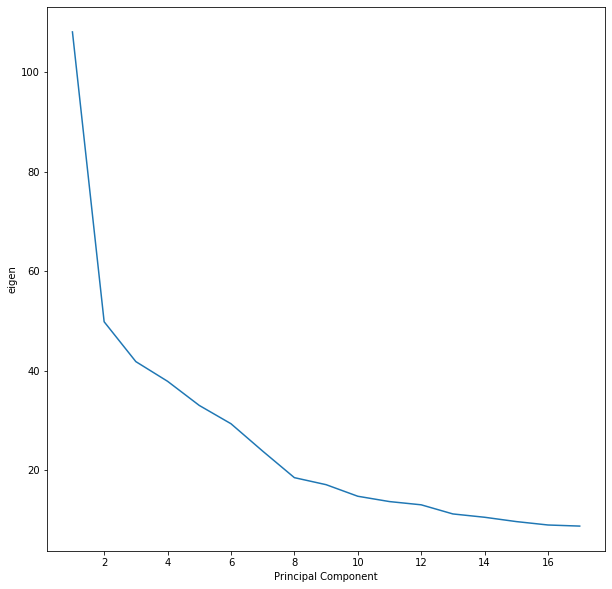

```python
plt.figure(figsize=(10,10))
sns.lineplot(x='Principal Component', y='eigen', data=Eig)
plt.show()
```

Seems like 8 components is the optimum efficient from kernel PCA, Again it is the matter of judgment, accuracy and what prediction you want from you analysis. It is subjective judgement which is 8 for us because we will not conduct further anaysis.

```python
### Again lets try simple KernelPCa with 'rbf' kernel and 8 components with other values as default
kpca= KernelPCA(n_components = 8, kernel = 'rbf')
```

```python
K_train = kpca.fit_transform(train)
```

```python
Var1 = np.var(K_train, axis=0)
```

```python
Var1
```

```
array([0.12135618, 0.05598423, 0.0469956 , 0.04256026, 0.03711571,
       0.03298816, 0.02681338, 0.02082696])
```

```python
PVE =  Var1/ np.sum(Var)
PVE
```

```
array([0.2397622 , 0.11060749, 0.09284874, 0.08408587, 0.07332915,
       0.06517437, 0.05297493, 0.04114762])
```

```python
len(kpca.alphas_)
```

```
891
```

```python
kpca.lambdas_
```

```
array([108.12835769,  49.8819515 ,  41.87307798,  37.92118761,
        33.07010019,  29.39244644,  23.89072284,  18.55682439])
```

```python
### lets try with four components
kpca= KernelPCA(n_components = 4, kernel = 'rbf')
K_train = kpca.fit_transform(train)
Var1 = np.var(K_train, axis=0)
PVE =  Var1/ np.sum(Var)
PVE
```

```
array([0.2397622 , 0.11060749, 0.09284874, 0.08408587])
```